# AR Lab Generation — Benchmark Statistics

```python
df = pd.DataFrame(RECORDS)            # ALL runs (successes + failures)
OK = df[df.success].copy()           # successful runs only
FAIL = df[~df.success].copy()        # failed runs

LEVELS = ['L1', 'L3', 'L4']  # L2 retired (issue #31)
PROVIDERS = ['openai', 'anthropic', 'google']
FULL = OK[OK.level != 'L1']  # L3-L4 successes (any spec)
# Structural columns differ by spec, so slice before aggregating shape.
FULL_JSON = FULL[FULL.spec_type == 'json_lab']                       # json_lab shape
FULL_ARLEM = FULL[FULL.spec_type.isin(['arlem', 'arlem_simple'])]    # ARLEM shape

def agg(frame, by):
    """Standard cost/token/time aggregation grouped by a column."""
    g = frame.groupby(by)
    out = pd.DataFrame({
        'runs': g.size(),
        'avg_cost_usd': g.cost_usd.mean().round(4),
        'total_cost_usd': g.cost_usd.sum().round(2),
        'avg_total_tokens': g.total_tokens.mean().round(0),
        'avg_completion_tokens': g.completion_tokens.mean().round(0),
        'avg_wall_s': g.wall_s.mean().round(1),
        'avg_tokens_per_sec': g.tokens_per_sec.mean().round(1),
    })
    return out

def struct_agg(frame, by):
    """json_lab structural-shape aggregation (use on FULL_JSON, L3-L4)."""
    g = frame.groupby(by)
    out = pd.DataFrame({
        'runs': g.size(),
        'avg_modules': g.num_modules.mean().round(1),
        'avg_clips': g.num_clips.mean().round(1),
        'avg_clips_per_module': g.clips_per_module.mean().round(1),
        'avg_objects': g.num_objects.mean().round(1),
        'avg_unique_objects': g.num_unique_objects.mean().round(1),
        'avg_components': g.num_components.mean().round(1),
        'avg_obj_changes': g.num_object_changes.mean().round(1),
    })
    return out

def arlem_agg(frame, by):
    """ARLEM structural-shape aggregation (use on FULL_ARLEM, L3-L4)."""
    g = frame.groupby(by)
    out = pd.DataFrame({
        'runs': g.size(),
        'avg_things': g.num_things.mean().round(1),
        'avg_places': g.num_places.mean().round(1),
        'avg_predicates': g.num_predicates.mean().round(1),
        'avg_actions': g.num_actions.mean().round(1),
        'avg_activates': g.total_activates.mean().round(1),
        'avg_triggers': g.total_triggers.mean().round(1),
        'avg_pois': g.total_pois.mean().round(1),
    })
    return out

print(f'{len(df)} runs ({int(df.success.sum())} ok / {int((~df.success).sum())} failed) | {df.model.nunique()} models | levels {sorted(df.level.unique())} | specs {sorted(df.spec_type.dropna().unique())} | labs {df.lab_name.nunique()}')
```

```
385 runs (351 ok / 34 failed) | 11 models | levels ['L1', 'L3', 'L4'] | specs ['arlem', 'arlem_simple', 'json_lab'] | labs 5
```

## Slice it yourself

The full flat table lives in `Artifacts/Data/Benchmark/Reports/benchmark_runs_wave2_repriced.csv`, or load it live from the source metrics files:

```
import sys; sys.path.insert(0, 'Code/Testing')
from benchmark_dataframe import load_runs
df = load_runs()
df[df.provider == 'anthropic'].wall_s.mean()       # avg speed, one provider
df.groupby('level').num_clips.mean()               # avg clips per level
```

Every column available:

```python
list(df.columns)
```

```
['model',
 'display_name',
 'provider',
 'size',
 'level',
 'structure',
 'lab_name',
 'spec_type',
 'timestamp',
 'success',
 'fail_mode',
 'had_usage',
 'prompt_tokens',
 'completion_tokens',
 'total_tokens',
 'cost_usd',
 'duration_ms',
 'wall_s',
 'retries',
 'parse_errors',
 'api_errors',
 'num_objectives',
 'num_modules',
 'num_objects',
 'num_clips',
 'num_components',
 'num_object_changes',
 'num_text_labels',
 'num_educational_objectives',
 'num_unique_prefabs',
 'num_unique_objects',
 'num_things',
 'num_places',
 'num_persons',
 'num_sensors',
 'num_devices',
 'num_apps',
 'num_detectables',
 'num_primitives',
 'num_predicates',
```

[output cut: 15 more lines]

```
 'texture_refs',
 'prefab_refs',
 'audio_refs',
 'audio_unique',
 'clips_per_module',
 'objects_per_module',
 'components_per_object',
 'changes_per_clip',
 'tokens_per_sec',
 'novel_prefabs_per_module',
 'novel_textures_per_module',
 'novel_prefabs_per_object',
 'novel_textures_per_object',
 'audio_per_clip',
 'cost_usd_recorded']
```

## Cost & tokens

Every spec runs free-decode (generate + validate/retry), so the provider-reported `cost_usd` / `total_tokens` are the real figures — there is no Gemini schema-token adjustment to fold in. Aggregations here cover all specs; the **By spec** cut compares json_lab vs ARLEM full vs simplified.

```python
# Successful runs only (failed-run spend is covered in its own section).
print('By provider:'); display(agg(OK, 'provider'))
print('By spec:'); display(agg(OK, 'spec_type'))
print('By level:'); display(agg(OK, 'level').reindex(LEVELS))
print('By model:'); display(agg(OK, 'display_name').sort_values('avg_cost_usd'))
```

```
By provider:
```

| provider | runs | avg_cost_usd | total_cost_usd | avg_total_tokens | avg_completion_tokens | avg_wall_s | avg_tokens_per_sec |
| --- | --- | --- | --- | --- | --- | --- | --- |
| anthropic | 102 | 0.2086 | 21.28 | 32049.0 | 11306.0 | 86.1 | 131.7 |
| google | 115 | 0.0583 | 6.71 | 22144.0 | 4544.0 | 40.5 | 169.3 |
| openai | 134 | 0.1498 | 20.07 | 21385.0 | 8415.0 | 64.9 | 149.1 |

```
By spec:
```

| spec_type | runs | avg_cost_usd | total_cost_usd | avg_total_tokens | avg_completion_tokens | avg_wall_s | avg_tokens_per_sec |
| --- | --- | --- | --- | --- | --- | --- | --- |
| arlem | 90 | 0.2060 | 18.54 | 42284.0 | 10856.0 | 80.3 | 165.4 |
| arlem_simple | 102 | 0.0795 | 8.11 | 17348.0 | 5377.0 | 41.0 | 156.7 |
| json_lab | 159 | 0.1347 | 21.41 | 19534.0 | 8037.0 | 67.5 | 138.4 |

```
By level:
```

| level | runs | avg_cost_usd | total_cost_usd | avg_total_tokens | avg_completion_tokens | avg_wall_s | avg_tokens_per_sec |
| --- | --- | --- | --- | --- | --- | --- | --- |
| L1 | 55 | 0.0170 | 0.93 | 2743.0 | 1355.0 | 15.0 | 115.9 |
| L3 | 149 | 0.1231 | 18.34 | 22643.0 | 6976.0 | 56.1 | 155.8 |
| L4 | 147 | 0.1959 | 28.79 | 35077.0 | 11492.0 | 88.2 | 158.5 |

```
By model:
```

| display_name | runs | avg_cost_usd | total_cost_usd | avg_total_tokens | avg_completion_tokens | avg_wall_s | avg_tokens_per_sec |
| --- | --- | --- | --- | --- | --- | --- | --- |
| Gemini 2.5 Flash Lite | 12 | 0.0015 | 0.02 | 7398.0 | 2672.0 | 20.0 | 230.2 |
| Gemini 3.1 Flash Lite | 34 | 0.0065 | 0.22 | 14704.0 | 2235.0 | 7.1 | 298.8 |
| GPT-5.4 Nano | 29 | 0.0146 | 0.42 | 26063.0 | 8953.0 | 58.5 | 151.6 |
| GPT-5.4 Mini | 35 | 0.0365 | 1.28 | 19335.0 | 5869.0 | 27.7 | 201.8 |
| Gemini 3.5 Flash | 35 | 0.0777 | 2.72 | 26285.0 | 6107.0 | 47.7 | 117.8 |
| Claude Haiku 4.5 | 32 | 0.0799 | 2.56 | 34325.0 | 11398.0 | 71.7 | 157.5 |
| Gemini 3.1 Pro | 34 | 0.1103 | 3.75 | 30525.0 | 5904.0 | 73.7 | 71.5 |
| Claude Sonnet 5 | 35 | 0.1505 | 5.27 | 31000.0 | 11059.0 | 77.1 | 137.9 |
| GPT-5.4 | 35 | 0.1530 | 5.36 | 20473.0 | 8147.0 | 52.5 | 157.0 |
| GPT-5.5 | 35 | 0.3719 | 13.02 | 20471.0 | 10782.0 | 120.1 | 86.4 |
| Claude Opus 4.8 | 35 | 0.3845 | 13.46 | 31017.0 | 11470.0 | 108.3 | 101.9 |

## Generation speed

`avg_wall_s` is end-to-end wall-clock time per run; `avg_tokens_per_sec` is completion throughput (completion tokens ÷ API duration).

```python
speed_cols = ['runs', 'avg_wall_s', 'avg_tokens_per_sec']
print('By provider:'); display(agg(OK, 'provider')[speed_cols])
print('By level:'); display(agg(OK, 'level').reindex(LEVELS)[speed_cols])
print('By model:'); display(agg(OK, 'display_name')[speed_cols].sort_values('avg_wall_s'))
```

```
By provider:
```

| provider | runs | avg_wall_s | avg_tokens_per_sec |
| --- | --- | --- | --- |
| anthropic | 102 | 86.1 | 131.7 |
| google | 115 | 40.5 | 169.3 |
| openai | 134 | 64.9 | 149.1 |

```
By level:
```

| level | runs | avg_wall_s | avg_tokens_per_sec |
| --- | --- | --- | --- |
| L1 | 55 | 15.0 | 115.9 |
| L3 | 149 | 56.1 | 155.8 |
| L4 | 147 | 88.2 | 158.5 |

```
By model:
```

| display_name | runs | avg_wall_s | avg_tokens_per_sec |
| --- | --- | --- | --- |
| Gemini 3.1 Flash Lite | 34 | 7.1 | 298.8 |
| Gemini 2.5 Flash Lite | 12 | 20.0 | 230.2 |
| GPT-5.4 Mini | 35 | 27.7 | 201.8 |
| Gemini 3.5 Flash | 35 | 47.7 | 117.8 |
| GPT-5.4 | 35 | 52.5 | 157.0 |
| GPT-5.4 Nano | 29 | 58.5 | 151.6 |
| Claude Haiku 4.5 | 32 | 71.7 | 157.5 |
| Gemini 3.1 Pro | 34 | 73.7 | 71.5 |
| Claude Sonnet 5 | 35 | 77.1 | 137.9 |
| Claude Opus 4.8 | 35 | 108.3 | 101.9 |
| GPT-5.5 | 35 | 120.1 | 86.4 |

## json_lab structural output (L3–L4)

Shape of the generated **json_lab** labs: modules per lab, clips per module, objects (and how many were distinct), and components created. Restricted to `FULL_JSON` (json_lab, L3–L4); L1 outlines and ARLEM runs are excluded.

```python
print('By level:'); display(struct_agg(FULL_JSON, 'level').reindex(['L3','L4']))
print('By provider:'); display(struct_agg(FULL_JSON, 'provider'))
print('By model:'); display(struct_agg(FULL_JSON, 'display_name').sort_values('avg_clips', ascending=False))
```

```
By level:
```

| level | runs | avg_modules | avg_clips | avg_clips_per_module | avg_objects | avg_unique_objects | avg_components | avg_obj_changes |
| --- | --- | --- | --- | --- | --- | --- | --- | --- |
| L3 | 53 | 3.3 | 11.8 | 3.6 | 20.3 | 20.1 | 8.5 | 32.2 |
| L4 | 51 | 7.8 | 23.5 | 3.0 | 41.6 | 41.1 | 19.3 | 52.7 |

```
By provider:
```

| provider | runs | avg_modules | avg_clips | avg_clips_per_module | avg_objects | avg_unique_objects | avg_components | avg_obj_changes |
| --- | --- | --- | --- | --- | --- | --- | --- | --- |
| anthropic | 30 | 6.1 | 20.7 | 3.6 | 33.5 | 33.0 | 20.6 | 40.1 |
| google | 34 | 4.7 | 11.3 | 2.6 | 19.8 | 19.2 | 9.6 | 18.1 |
| openai | 40 | 5.7 | 20.5 | 3.6 | 38.1 | 38.1 | 12.2 | 64.4 |

```
By model:
```

| display_name | runs | avg_modules | avg_clips | avg_clips_per_module | avg_objects | avg_unique_objects | avg_components | avg_obj_changes |
| --- | --- | --- | --- | --- | --- | --- | --- | --- |
| GPT-5.5 | 10 | 6.7 | 26.9 | 4.1 | 51.7 | 51.7 | 15.2 | 99.7 |
| Claude Opus 4.8 | 10 | 6.2 | 22.5 | 3.8 | 35.0 | 33.5 | 26.8 | 54.4 |
| GPT-5.4 | 10 | 6.3 | 22.0 | 3.7 | 37.6 | 37.6 | 12.9 | 58.4 |
| GPT-5.4 Nano | 10 | 5.7 | 21.4 | 3.8 | 38.2 | 38.2 | 11.7 | 71.6 |
| Claude Sonnet 5 | 10 | 6.4 | 20.1 | 3.5 | 31.1 | 31.1 | 14.9 | 35.7 |
| Claude Haiku 4.5 | 10 | 5.6 | 19.4 | 3.5 | 34.3 | 34.3 | 20.2 | 30.1 |
| Gemini 3.1 Pro | 10 | 6.1 | 15.4 | 2.8 | 23.6 | 22.6 | 12.5 | 22.0 |
| Gemini 3.5 Flash | 10 | 5.9 | 14.2 | 2.7 | 31.2 | 31.0 | 18.9 | 27.4 |
| GPT-5.4 Mini | 10 | 4.1 | 11.6 | 2.8 | 24.8 | 24.8 | 9.2 | 28.1 |
| Gemini 2.5 Flash Lite | 4 | 3.5 | 9.5 | 3.4 | 14.5 | 13.2 | 0.0 | 16.2 |
| Gemini 3.1 Flash Lite | 10 | 2.6 | 5.1 | 2.1 | 6.6 | 6.3 | 1.1 | 5.6 |

### Clips by specificity level × provider

Does more prompt detail yield more clips, and does that hold across providers? (json_lab runs only.)

```python
if not FULL_JSON.empty:
    ct = FULL_JSON.pivot_table(index='provider', columns='level', values='num_clips', aggfunc='mean').round(1)
    display(ct)
else:
    print('No json_lab L3-L4 runs in this sweep.')
```

| level provider | L3 | L4 |
| --- | --- | --- |
| anthropic | 13.5 | 27.8 |
| google | 7.9 | 15.2 |
| openai | 14.2 | 26.8 |

## ARLEM structural output (L3–L4)

Shape of the generated **ARLEM** scenarios (`arlem` full + `arlem_simple`): workplace things/places/predicates and activity actions / activates / triggers / POIs. Restricted to `FULL_ARLEM` (L3–L4). json_lab's modules/clips/objects don't apply here; ARLEM has a single ARLEMScenario shape (no `--structure`). The **By spec** cut contrasts full vs simplified.

```python
if not FULL_ARLEM.empty:
    print('By spec:'); display(arlem_agg(FULL_ARLEM, 'spec_type'))
    print('By level:'); display(arlem_agg(FULL_ARLEM, 'level').reindex(['L3','L4']))
    print('By provider:'); display(arlem_agg(FULL_ARLEM, 'provider'))
    print('By model:'); display(arlem_agg(FULL_ARLEM, 'display_name').sort_values('avg_actions', ascending=False))
else:
    print('No ARLEM L3-L4 runs in this sweep.')
```

```
By spec:
```

| spec_type | runs | avg_things | avg_places | avg_predicates | avg_actions | avg_activates | avg_triggers | avg_pois |
| --- | --- | --- | --- | --- | --- | --- | --- | --- |
| arlem | 90 | 3.8 | 2.4 | 16.0 | 7.4 | 12.3 | 10.7 | 12.9 |
| arlem_simple | 102 | 3.5 | 2.2 | 13.3 | 6.6 | 10.0 | 7.4 | 10.1 |

```
By level:
```

| level | runs | avg_things | avg_places | avg_predicates | avg_actions | avg_activates | avg_triggers | avg_pois |
| --- | --- | --- | --- | --- | --- | --- | --- | --- |
| L3 | 96 | 3.4 | 2.3 | 11.9 | 6.1 | 8.6 | 8.0 | 10.9 |
| L4 | 96 | 3.9 | 2.4 | 17.3 | 7.8 | 13.5 | 9.9 | 11.9 |

```
By provider:
```

| provider | runs | avg_things | avg_places | avg_predicates | avg_actions | avg_activates | avg_triggers | avg_pois |
| --- | --- | --- | --- | --- | --- | --- | --- | --- |
| anthropic | 57 | 3.6 | 2.2 | 19.5 | 7.3 | 24.0 | 10.7 | 15.6 |
| google | 61 | 2.9 | 2.1 | 9.5 | 6.2 | 12.5 | 6.2 | 8.0 |
| openai | 74 | 4.3 | 2.6 | 15.0 | 7.3 | 0.0 | 9.9 | 11.0 |

```
By model:
```

| display_name | runs | avg_things | avg_places | avg_predicates | avg_actions | avg_activates | avg_triggers | avg_pois |
| --- | --- | --- | --- | --- | --- | --- | --- | --- |
| Gemini 2.5 Flash Lite | 3 | 5.0 | 2.0 | 14.3 | 8.3 | 22.0 | 9.7 | 12.0 |
| GPT-5.5 | 20 | 4.6 | 2.6 | 21.9 | 8.0 | 0.0 | 13.3 | 20.2 |
| Claude Sonnet 5 | 20 | 4.6 | 2.4 | 21.0 | 7.9 | 25.3 | 12.2 | 15.8 |
| GPT-5.4 | 20 | 3.6 | 2.4 | 16.8 | 7.8 | 0.0 | 11.2 | 8.0 |
| Claude Opus 4.8 | 20 | 3.2 | 2.2 | 17.0 | 7.0 | 27.0 | 11.6 | 16.4 |
| Gemini 3.5 Flash | 20 | 3.0 | 2.0 | 12.1 | 6.9 | 15.0 | 6.9 | 13.0 |
| Claude Haiku 4.5 | 17 | 3.1 | 2.1 | 20.5 | 6.8 | 18.9 | 7.9 | 14.4 |
| GPT-5.4 Nano | 14 | 5.4 | 2.9 | 9.6 | 6.7 | 0.0 | 7.6 | 8.3 |
| GPT-5.4 Mini | 20 | 3.8 | 2.6 | 10.0 | 6.6 | 0.0 | 6.6 | 6.9 |
| Gemini 3.1 Pro | 19 | 3.1 | 2.1 | 9.4 | 6.3 | 16.2 | 6.3 | 7.6 |
| Gemini 3.1 Flash Lite | 19 | 2.2 | 2.1 | 6.1 | 5.0 | 4.7 | 4.9 | 2.4 |

### Trigger-mode mix (ARLEM)

How the generated activities advance between steps. Full ARLEM allows click/voice/detect/sensor; simplified is limited to click/detect.

```python
trig_cols = ['trigger_click', 'trigger_voice', 'trigger_detect', 'trigger_sensor']
if not FULL_ARLEM.empty:
    display(FULL_ARLEM.groupby('spec_type')[trig_cols].mean().round(1))
else:
    print('No ARLEM L3-L4 runs in this sweep.')
```

| spec_type | trigger_click | trigger_voice | trigger_detect | trigger_sensor |
| --- | --- | --- | --- | --- |
| arlem | 5.7 | 3.9 | 1.2 | 0.0 |
| arlem_simple | 5.8 | 0.0 | 1.6 | 0.0 |

## Novel assets (json_lab, L3–L4)

Novel assets are a **json_lab** concept (invented prefab/texture names); ARLEM has no comparable asset library, so this section restricts to `FULL_JSON`.

Today the headset only has the **moon-lab** asset library (textures `2k_earth_daymap`/`2k_moon`/`2k_sun`/`balldimpled`; prefabs `SunPrefab`/`moveableSphere`/`clickableSphere`/`tinySphere`/`textPrefab`/`robotIdle`). To build a lab on any other topic, a model must **invent** asset names — prefabs/models and textures we don't have and would have to author. `novel_textures` / `novel_prefabs` count the **distinct** invented assets per lab (deduped across modules — a prefab reused three times is one asset to build); the `*_refs` columns count how many object-instances point at one.

**Audio is different:** there is no existing audio library at all, so every `audioClip` is novel by definition. Reporting it as 'novel' would always be 100%, so audio is shown as **volume/density** (`audio_per_clip`) instead — effectively, what share of clips carry narration audio.

```python
def asset_agg(frame, by):
    """Novel-asset aggregation (use on L3-L4 only)."""
    g = frame.groupby(by)
    out = pd.DataFrame({
        'runs': g.size(),
        'avg_novel_prefabs': g.novel_prefabs.mean().round(1),
        'avg_novel_textures': g.novel_textures.mean().round(1),
        'novel_prefabs_per_module': g.novel_prefabs_per_module.mean().round(2),
        'novel_prefabs_per_object': g.novel_prefabs_per_object.mean().round(2),
        'novel_textures_per_module': g.novel_textures_per_module.mean().round(2),
        'audio_per_clip': g.audio_per_clip.mean().round(2),
    })
    return out

print('By level:'); display(asset_agg(FULL_JSON, 'level').reindex(['L3','L4']))
print('By provider:'); display(asset_agg(FULL_JSON, 'provider'))
print('By model size:'); display(asset_agg(FULL_JSON, 'size').reindex(['small','medium','large']))
print('By model:'); display(asset_agg(FULL_JSON, 'display_name').sort_values('avg_novel_prefabs', ascending=False))
```

```
By level:
```

| level | runs | avg_novel_prefabs | avg_novel_textures | novel_prefabs_per_module | novel_prefabs_per_object | novel_textures_per_module | audio_per_clip |
| --- | --- | --- | --- | --- | --- | --- | --- |
| L3 | 53 | 7.4 | 3.0 | 2.22 | 0.37 | 0.91 | 0.92 |
| L4 | 51 | 11.7 | 4.3 | 1.46 | 0.27 | 0.51 | 0.97 |

```
By provider:
```

| provider | runs | avg_novel_prefabs | avg_novel_textures | novel_prefabs_per_module | novel_prefabs_per_object | novel_textures_per_module | audio_per_clip |
| --- | --- | --- | --- | --- | --- | --- | --- |
| anthropic | 30 | 8.7 | 1.5 | 1.60 | 0.30 | 0.31 | 1.01 |
| google | 34 | 5.7 | 0.8 | 1.29 | 0.29 | 0.27 | 0.83 |
| openai | 40 | 13.4 | 7.7 | 2.51 | 0.37 | 1.40 | 1.00 |

```
By model size:
```

| size | runs | avg_novel_prefabs | avg_novel_textures | novel_prefabs_per_module | novel_prefabs_per_object | novel_textures_per_module | audio_per_clip |
| --- | --- | --- | --- | --- | --- | --- | --- |
| small | 44 | 7.4 | 1.4 | 1.62 | 0.29 | 0.42 | 1.00 |
| medium | 30 | 10.1 | 4.7 | 1.98 | 0.34 | 0.84 | 1.00 |
| large | 30 | 12.1 | 5.8 | 2.04 | 0.36 | 1.02 | 0.81 |

```
By model:
```

| display_name | runs | avg_novel_prefabs | avg_novel_textures | novel_prefabs_per_module | novel_prefabs_per_object | novel_textures_per_module | audio_per_clip |
| --- | --- | --- | --- | --- | --- | --- | --- |
| GPT-5.5 | 10 | 18.5 | 14.2 | 2.86 | 0.37 | 2.18 | 1.00 |
| GPT-5.4 | 10 | 13.0 | 11.6 | 2.44 | 0.37 | 2.08 | 1.00 |
| GPT-5.4 Nano | 10 | 11.7 | 0.3 | 2.12 | 0.32 | 0.08 | 1.00 |
| GPT-5.4 Mini | 10 | 10.2 | 4.6 | 2.62 | 0.42 | 1.27 | 1.00 |
| Claude Sonnet 5 | 10 | 9.7 | 1.6 | 1.80 | 0.35 | 0.27 | 1.00 |
| Claude Opus 4.8 | 10 | 9.3 | 2.4 | 1.69 | 0.31 | 0.55 | 1.02 |
| Gemini 3.1 Pro | 10 | 8.4 | 0.9 | 1.58 | 0.39 | 0.32 | 0.42 |
| Gemini 3.5 Flash | 10 | 7.6 | 0.8 | 1.71 | 0.32 | 0.17 | 1.01 |
| Claude Haiku 4.5 | 10 | 7.2 | 0.4 | 1.29 | 0.25 | 0.11 | 1.00 |
| Gemini 2.5 Flash Lite | 4 | 6.5 | 2.2 | 2.01 | 0.36 | 1.04 | 1.00 |
| Gemini 3.1 Flash Lite | 10 | 0.7 | 0.0 | 0.31 | 0.13 | 0.00 | 1.00 |

### Novel prefabs by specificity level × provider

Does more prompt detail change how many assets the model invents, and does that hold across providers? (A flat row would mean asset count is driven by lab size, not prompt specificity.)

```python
if not FULL_JSON.empty:
    ct = FULL_JSON.pivot_table(index='provider', columns='level', values='novel_prefabs', aggfunc='mean').round(1)
    display(ct)
    print('Per-module (size-normalized):')
    display(FULL_JSON.pivot_table(index='provider', columns='level', values='novel_prefabs_per_module', aggfunc='mean').round(2))
else:
    print('No json_lab L3-L4 runs in this sweep.')
```

| level provider | L3 | L4 |
| --- | --- | --- |
| anthropic | 6.2 | 11.3 |
| google | 4.3 | 7.2 |
| openai | 11.0 | 15.8 |

```
Per-module (size-normalized):
```

| level provider | L3 | L4 |
| --- | --- | --- |
| anthropic | 1.85 | 1.34 |
| google | 1.71 | 0.82 |
| openai | 2.96 | 2.06 |

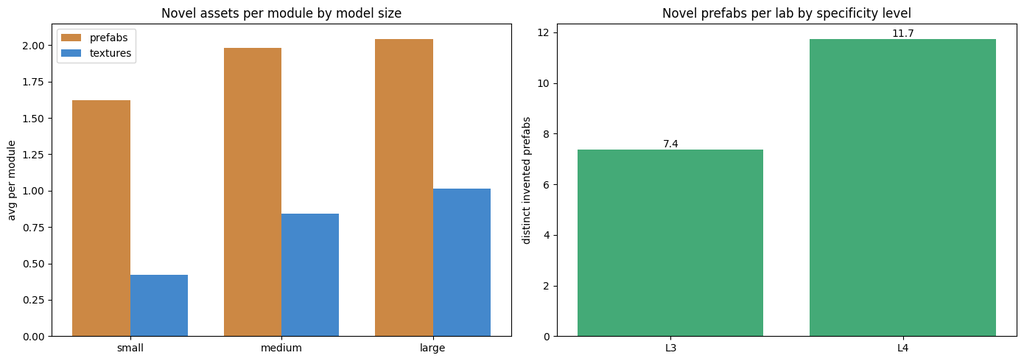

```python
fig, axes = plt.subplots(1, 2, figsize=(14, 5))

# Novel prefabs & textures per module by model size (json_lab only)
order = ['small', 'medium', 'large']
pm = FULL_JSON.groupby('size').novel_prefabs_per_module.mean().reindex(order)
tm = FULL_JSON.groupby('size').novel_textures_per_module.mean().reindex(order)
x = np.arange(len(order)); w = 0.38
axes[0].bar(x - w/2, pm.values, w, label='prefabs', color='#c84')
axes[0].bar(x + w/2, tm.values, w, label='textures', color='#48c')
axes[0].set_xticks(x); axes[0].set_xticklabels(order)
axes[0].set_title('Novel assets per module by model size')
axes[0].set_ylabel('avg per module'); axes[0].legend()

# Novel prefabs per lab by specificity level (json_lab only)
lv = ['L3', 'L4']
k = FULL_JSON.groupby('level').novel_prefabs.mean().reindex(lv)
axes[1].bar(lv, k.values, color='#4a7')
axes[1].set_title('Novel prefabs per lab by specificity level')
axes[1].set_ylabel('distinct invented prefabs')
for i, v in enumerate(k.values):
    axes[1].annotate(f'{v:.1f}', (i, v), ha='center', va='bottom')

plt.tight_layout(); plt.show()
```

## Failed runs

Failures live only in the `suite_results_*.json` sweeps (a successful run also writes a standalone metrics file; a failed one does not). They split cleanly into two kinds, keyed on whether the run actually reached the model and burned tokens (`had_usage`):

- **Billable failures** — `truncation (max_tokens)` and `schema validation` retries generated real output before failing, so they carry meaningful token / cost / time stats (and are often *more* expensive than a success, because instructor retried).
- **No-op failures** — `404 model-not-found` and config errors never reached the model: 0 tokens, $0, sub-second. They have no relevant statistics and are excluded from the cost/token aggregates below.

```python
# Overview: how common is each failure mode, and is it billable?
ov = FAIL.groupby('fail_mode').agg(
    failed_runs=('model', 'size'),
    billable=('had_usage', 'sum'),
    total_tokens=('total_tokens', 'sum'),
    total_cost_usd=('cost_usd', 'sum'),
    avg_wall_s=('wall_s', 'mean'),
).round({'total_cost_usd': 2, 'avg_wall_s': 1}).sort_values('failed_runs', ascending=False)
print('Failure modes (the "common errors" breakdown):')
display(ov)
wasted = FAIL.cost_usd.sum(); spent = OK.cost_usd.sum()
print(f'Spend on failed runs: ${wasted:.2f}  ({wasted / (wasted + spent):.1%} of total ${wasted + spent:.2f}) — all from billable failures.')
```

```
Failure modes (the "common errors" breakdown):
```

| fail_mode | failed_runs | billable | total_tokens | total_cost_usd | avg_wall_s |
| --- | --- | --- | --- | --- | --- |
| schema validation | 28 | 28 | 1790104 | 1.41 | 74.8 |
| other | 6 | 6 | 21450 | 0.00 | 39.2 |

```
Spend on failed runs: $1.41  (2.8% of total $49.47) — all from billable failures.
```

### Billable failures — what they cost

Token/cost/time for the failures that actually did work, by model. These are the runs worth attention: real money spent on output that didn't validate or got truncated.

```python
BILL = FAIL[FAIL.had_usage]
by_model = BILL.groupby('display_name').agg(
    failed_runs=('model', 'size'),
    total_tokens=('total_tokens', 'sum'),
    total_cost_usd=('cost_usd', 'sum'),
    avg_wall_s=('wall_s', 'mean'),
    avg_retries=('retries', 'mean'),
).round({'total_cost_usd': 3, 'avg_wall_s': 1, 'avg_retries': 1})
display(by_model.sort_values('total_cost_usd', ascending=False))
print('By level:')
display(BILL.groupby('level').agg(
    failed_runs=('model', 'size'),
    avg_tokens=('total_tokens', 'mean'),
    avg_cost_usd=('cost_usd', 'mean'),
    avg_wall_s=('wall_s', 'mean'),
).round(2))
```

| display_name | failed_runs | total_tokens | total_cost_usd | avg_wall_s | avg_retries |
| --- | --- | --- | --- | --- | --- |
| Claude Haiku 4.5 | 3 | 293675 | 0.607 | 159.4 | 7.0 |
| Gemini 3.1 Pro | 1 | 111170 | 0.452 | 197.0 | 7.0 |
| Gemini 2.5 Flash Lite | 23 | 1009652 | 0.169 | 45.1 | 4.7 |
| GPT-5.4 Nano | 6 | 362317 | 0.167 | 100.8 | 7.0 |
| Gemini 3.1 Flash Lite | 1 | 34740 | 0.014 | 12.6 | 7.0 |

```
By level:
```

| level | failed_runs | avg_tokens | avg_cost_usd | avg_wall_s |
| --- | --- | --- | --- | --- |
| L3 | 16 | 47581.88 | 0.03 | 47.87 |
| L4 | 18 | 58346.89 | 0.05 | 86.94 |

### No-op failures — no relevant statistics

```python
NOOP = FAIL[~FAIL.had_usage]
display(NOOP[['display_name', 'level', 'lab_name', 'fail_mode', 'total_tokens', 'cost_usd', 'wall_s']].reset_index(drop=True))
```

|  | display_name | level | lab_name | fail_mode | total_tokens | cost_usd | wall_s |
| --- | --- | --- | --- | --- | --- | --- | --- |

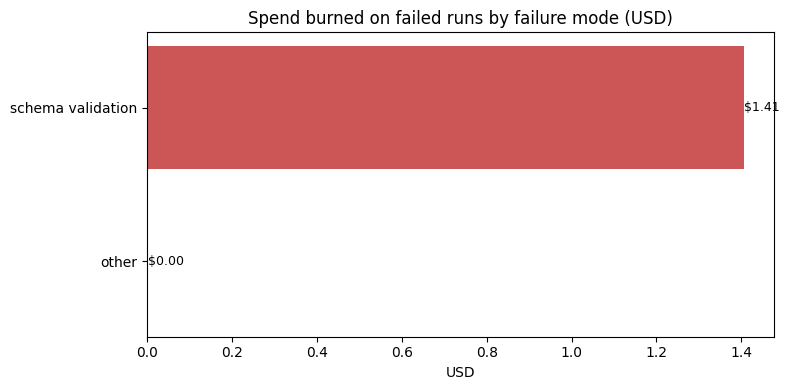

```python
# Cost burned per failure mode (billable only).
fig, ax = plt.subplots(figsize=(8, 4))
fc = BILL.groupby('fail_mode').cost_usd.sum().sort_values()
ax.barh(fc.index, fc.values, color='#c55')
ax.set_title('Spend burned on failed runs by failure mode (USD)')
ax.set_xlabel('USD')
for i, v in enumerate(fc.values):
    ax.annotate(f'${v:.2f}', (v, i), va='center', fontsize=9)
plt.tight_layout(); plt.show()
```

## Charts

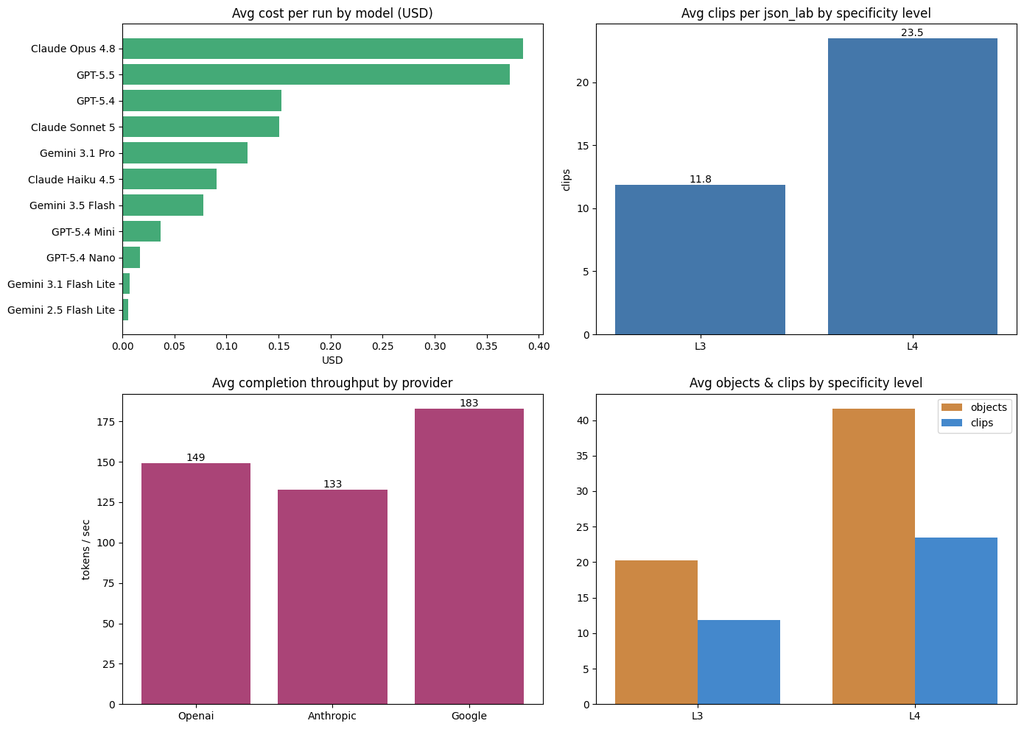

```python
fig, axes = plt.subplots(2, 2, figsize=(14, 10))

# 1. Avg cost per run by model
c = df.groupby('display_name').cost_usd.mean().sort_values()
axes[0, 0].barh(c.index, c.values, color='#4a7')
axes[0, 0].set_title('Avg cost per run by model (USD)')
axes[0, 0].set_xlabel('USD')

# 2. Avg clips by level (json_lab, L3-L4)
k = FULL_JSON.groupby('level').num_clips.mean().reindex(['L3','L4'])
axes[0, 1].bar(k.index, k.values, color='#47a')
axes[0, 1].set_title('Avg clips per json_lab by specificity level')
axes[0, 1].set_ylabel('clips')
for i, v in enumerate(k.values):
    axes[0, 1].annotate(f'{v:.1f}', (i, v), ha='center', va='bottom')

# 3. Avg throughput by provider
s = df.groupby('provider').tokens_per_sec.mean().reindex(PROVIDERS)
axes[1, 0].bar([p.capitalize() for p in s.index], s.values, color='#a47')
axes[1, 0].set_title('Avg completion throughput by provider')
axes[1, 0].set_ylabel('tokens / sec')
for i, v in enumerate(s.values):
    axes[1, 0].annotate(f'{v:.0f}', (i, v), ha='center', va='bottom')

# 4. Avg objects vs clips by level (json_lab)
lv = ['L3', 'L4']
objs = FULL_JSON.groupby('level').num_objects.mean().reindex(lv)
clps = FULL_JSON.groupby('level').num_clips.mean().reindex(lv)
x = np.arange(len(lv)); w = 0.38
axes[1, 1].bar(x - w/2, objs.values, w, label='objects', color='#c84')
axes[1, 1].bar(x + w/2, clps.values, w, label='clips', color='#48c')
axes[1, 1].set_xticks(x); axes[1, 1].set_xticklabels(lv)
axes[1, 1].set_title('Avg objects & clips by specificity level')
axes[1, 1].legend()

plt.tight_layout(); plt.show()
```

## Notes

- Cost/token figures are the raw provider-reported `cost_usd` / `total_tokens`. Every spec runs free-decode, so there is no Gemini schema-token adjustment (the old `effective_*` columns were retired).
- Structural sections split by **spec_type**: json_lab shape (modules/clips/objects) uses `FULL_JSON`; ARLEM shape (things/places/actions/triggers/POIs) uses `FULL_ARLEM`. A row carries 0 for the columns that don't apply to its spec.
- Structural counts are over **successful** L3–L4 runs only; a model that failed a level contributes no row there.
- Failed-run stats use `had_usage` (`total_tokens > 0`) to separate billable failures from no-op ones; only billable failures enter the cost/token aggregates.
- `num_components` is the count of components created per lab ("new components made"); the per-type breakdown lives in the source metrics' `component_types` if a finer cut is needed.
- Novel-asset counts are computed by re-reading each saved `*_output.json` at load time (no re-running of the sweep); membership in the known moon-lab library is case-insensitive. The invented asset *names* aren't in the CSV but are available per-lab via `lab_metrics.analyze_assets(output_json)` (`novel_prefab_names` / `novel_texture_names`) for qualitative review.